# Political families: 1989-2019

### Document History

Original Publish Date: 18 August, 2021

Updated on: 04:08 PM – 19 August, 2021

# Preliminary analysis

## Data summary

No

Variable

Stats / Values

Freqs (% of Valid)

Graph

Missing

1

state_name  
[character]

1. Uttar Pradesh  
2. Maharashtra  
3. Bihar  
4. West Bengal  
5. Tamil Nadu  
6. Andhra Pradesh  
7. Madhya Pradesh  
8. Karnataka  
9. Gujarat  
10. Rajasthan  
[ 26 others ]

1488 (15.3%)  
864 ( 8.9%)  
856 ( 8.8%)  
756 ( 7.8%)  
700 ( 7.2%)  
654 ( 6.7%)  
632 ( 6.5%)  
504 ( 5.2%)  
468 ( 4.8%)  
450 ( 4.6%)  
2323 (24.0%)

0  
(0.0%)

2

year  
[integer]

Mean (sd) : 2002.2 (9.6)  
min < med < max:  
1989 < 1999 < 2019  
IQR (CV) : 13 (0)

1989 : 1054 (10.9%)  
1991 : 1041 (10.7%)  
1996 : 1086 (11.2%)  
1998 : 1086 (11.2%)  
1999 : 1086 (11.2%)  
2004 : 1086 (11.2%)  
2009 : 1086 (11.2%)  
2014 : 1086 (11.2%)  
2019 : 1084 (11.2%)

0  
(0.0%)

3

constituency_no  
[integer]

Mean (sd) : 20.1 (17.4)  
min < med < max:  
1 < 16 < 85  
IQR (CV) : 22 (0.9)

85 distinct values

0  
(0.0%)

4

position  
[integer]

Min : 1  
Mean : 1.5  
Max : 2

1 : 4849 (50.0%)  
2 : 4846 (50.0%)

0  
(0.0%)

5

caste_rec  
[character]

1. (Empty string)  
2. UC  
3. OBC  
4. SC  
5. IC  
6. ST  
7. MUSLIM  
8. UC MUSLIM  
9. IC SIKH  
10. UC CHRISTIAN  
[ 21 others ]

4026 (47.9%)  
1260 (15.0%)  
961 (11.4%)  
709 ( 8.4%)  
500 ( 5.9%)  
410 ( 4.9%)  
276 ( 3.3%)  
55 ( 0.7%)  
49 ( 0.6%)  
28 ( 0.3%)  
138 ( 1.6%)

1283  
(13.2%)

6

dyn  
[character]

1. (Empty string)  
2. 0  
3. 1  
4. Recheck

2169 (22.4%)  
5309 (54.8%)  
2193 (22.6%)  
24 ( 0.2%)

0  
(0.0%)

7

source  
[character]

1. TALHA  
2. (Empty string)  
3. Patrick French  
4. Not Known  
5. Arun  
6. Walru  
7. Rama  
8. TCPD  
9. The Hindu  
10. Saurov  
[ 40 others ]

2826 (29.1%)  
2272 (23.4%)  
917 ( 9.5%)  
664 ( 6.8%)  
395 ( 4.1%)  
325 ( 3.4%)  
197 ( 2.0%)  
168 ( 1.7%)  
153 ( 1.6%)  
142 ( 1.5%)  
1636 (16.9%)

0  
(0.0%)

8

background  
[character]

1. No significant political  
2. (Empty string)  
3. No significant family bac  
4. Family - Son  
5. Student politics  
6. Business  
7. Family  
8. RSS  
9. Family - Multiple connect  
10. Family-Son  
[ 1186 others ]

2189 (22.6%)  
2171 (22.4%)  
1396 (14.4%)  
188 ( 1.9%)  
158 ( 1.6%)  
118 ( 1.2%)  
94 ( 1.0%)  
86 ( 0.9%)  
76 ( 0.8%)  
56 ( 0.6%)  
3163 (32.6%)

0  
(0.0%)

9

notes  
[character]

1. (Empty string)  
2. Hindutva Movment  
3. Buisness  
4. Wealthy businessman with  
5. Trible Network  
6. Former MLA  
7. He started his political  
8. Daughter of Babu Jagjivan  
9. He started out as a stude  
10. He was a member of the Ak  
[ 1424 others ]

6285 (64.8%)  
34 ( 0.4%)  
15 ( 0.2%)  
15 ( 0.2%)  
11 ( 0.1%)  
10 ( 0.1%)  
10 ( 0.1%)  
9 ( 0.1%)  
9 ( 0.1%)  
9 ( 0.1%)  
3288 (33.9%)

0  
(0.0%)

10

election_type  
[character]

1. GE

9695 (100.0%)

0  
(0.0%)

11

assembly_no  
[integer]

Mean (sd) : 13 (2.6)  
min < med < max:  
9 < 13 < 17  
IQR (CV) : 4 (0.2)

9 : 1054 (10.9%)  
10 : 1041 (10.7%)  
11 : 1086 (11.2%)  
12 : 1086 (11.2%)  
13 : 1086 (11.2%)  
14 : 1086 (11.2%)  
15 : 1086 (11.2%)  
16 : 1086 (11.2%)  
17 : 1084 (11.2%)

0  
(0.0%)

12

month  
[integer]

Mean (sd) : 5.3 (2.6)  
min < med < max:  
3 < 4 < 11  
IQR (CV) : 1 (0.5)

3 : 1086 (11.2%)  
4 : 5428 (56.0%)  
5 : 1041 (10.7%)  
9 : 1086 (11.2%)  
11 : 1054 (10.9%)

0  
(0.0%)

13

poll_no  
[integer]

1 distinct value

0 : 9695 (100.0%)

0  
(0.0%)

14

delimid  
[integer]

Min : 3  
Mean : 3.3  
Max : 4

3 : 6439 (66.4%)  
4 : 3256 (33.6%)

0  
(0.0%)

15

candidate  
[character]

1. DELKAR MOHANBHAI SANJIBHA  
2. RADHA MOHAN SINGH  
3. RAM SINGH  
4. SHARAD YADAV  
5. MULAYAM SINGH YADAV  
6. PAWAN KUMAR BANSAL  
7. SHIBU SOREN  
8. AVTAR SINGH BHADANA  
9. BIREN SINGH ENGTI  
10. CHHEDI PASWAN  
[ 7798 others ]

8 ( 0.1%)  
8 ( 0.1%)  
8 ( 0.1%)  
8 ( 0.1%)  
7 ( 0.1%)  
7 ( 0.1%)  
7 ( 0.1%)  
6 ( 0.1%)  
6 ( 0.1%)  
6 ( 0.1%)  
9624 (99.3%)

[figure not shown]

0  
(0.0%)

16

sex  
[character]

1. F  
2. M

896 ( 9.2%)  
8799 (90.8%)

0  
(0.0%)

17

party  
[character]

1. INC  
2. BJP  
3. JD  
4. CPM  
5. SP  
6. BSP  
7. TDP  
8. DMK  
9. ADMK  
10. RJD  
[ 137 others ]

3080 (31.8%)  
2438 (25.1%)  
441 ( 4.5%)  
415 ( 4.3%)  
332 ( 3.4%)  
300 ( 3.1%)  
275 ( 2.8%)  
203 ( 2.1%)  
171 ( 1.8%)  
165 ( 1.7%)  
1875 (19.3%)

0  
(0.0%)

18

votes  
[integer]

Mean (sd) : 308817.2 (140069.1)  
min < med < max:  
9808 < 290524 < 1068569  
IQR (CV) : 171378 (0.5)

9600 distinct values

0  
(0.0%)

19

candidate_type  
[character]

1. (Empty string)  
2. GEN  
3. SC  
4. ST

3345 (34.5%)  
4689 (48.4%)  
1026 (10.6%)  
635 ( 6.5%)

0  
(0.0%)

20

valid_votes  
[integer]

Mean (sd) : 746253.6 (258827)  
min < med < max:  
25321 < 706830 < 1763757  
IQR (CV) : 315477.5 (0.3)

4833 distinct values

0  
(0.0%)

21

electors  
[integer]

Mean (sd) : 1226555 (349088.7)  
min < med < max:  
30069 < 1161683 < 3368399  
IQR (CV) : 422893 (0.3)

4834 distinct values

0  
(0.0%)

22

constituency_name  
[character]

1. AURANGABAD  
2. HAMIRPUR  
3. MAHARAJGANJ  
4. ADILABAD  
5. AGRA  
6. AJMER  
7. AKBARPUR  
8. AKOLA  
9. ALIGARH  
10. ALIPURDUARS  
[ 712 others ]

36 ( 0.4%)  
36 ( 0.4%)  
36 ( 0.4%)  
18 ( 0.2%)  
18 ( 0.2%)  
18 ( 0.2%)  
18 ( 0.2%)  
18 ( 0.2%)  
18 ( 0.2%)  
18 ( 0.2%)  
9461 (97.6%)

[figure not shown]

0  
(0.0%)

23

constituency_type  
[character]

1. GEN  
2. SC  
3. ST

7481 (77.2%)  
1444 (14.9%)  
770 ( 7.9%)

0  
(0.0%)

24

sub_region  
[character]

1. (Empty string)  
2. AVADH  
3. BUNDELKHAND  
4. DOAB  
5. EAST  
6. NORTH-EAST  
7. RUHELKHAND  
8. SEEMANDHRA  
9. TELENGANA  
10. WEST

8963 (92.4%)  
84 ( 0.9%)  
24 ( 0.2%)  
84 ( 0.9%)  
96 ( 1.0%)  
72 ( 0.7%)  
72 ( 0.7%)  
150 ( 1.5%)  
102 ( 1.1%)  
48 ( 0.5%)

0  
(0.0%)

25

n_cand  
[integer]

Mean (sd) : 14.1 (13.5)  
min < med < max:  
2 < 12 < 480  
IQR (CV) : 9 (1)

78 distinct values

0  
(0.0%)

26

turnout_percentage  
[numeric]

Mean (sd) : 60.9 (12.1)  
min < med < max:  
5 < 60.7 < 91.7  
IQR (CV) : 17.3 (0.2)

2967 distinct values

0  
(0.0%)

27

vote_share_percentage  
[numeric]

Mean (sd) : 41.2 (10.5)  
min < med < max:  
6.4 < 41.2 < 97.7  
IQR (CV) : 14.6 (0.3)

3776 distinct values

0  
(0.0%)

28

deposit_lost  
[character]

1. no  
2. yes

9656 (99.6%)  
39 ( 0.4%)

0  
(0.0%)

29

margin  
[integer]

Mean (sd) : 140505 (120035.7)  
min < med < max:  
0 < 107250 < 712215  
IQR (CV) : 173438.5 (0.9)

9534 distinct values

0  
(0.0%)

30

margin_percentage  
[numeric]

Mean (sd) : 18.5 (13.6)  
min < med < max:  
0 < 15.7 < 97.2  
IQR (CV) : 23.1 (0.7)

3973 distinct values

0  
(0.0%)

31

enop  
[numeric]

Mean (sd) : 2.8 (0.7)  
min < med < max:  
1 < 2.6 < 10  
IQR (CV) : 0.9 (0.3)

63 distinct values

0  
(0.0%)

32

pid  
[character]

1. GEAP30917  
2. GEAP50805  
3. GEAP30298  
4. GEAP30928  
5. GEAP50659  
6. GEAP81781  
7. GEBR42656  
8. AEUP153597  
9. GEAP64985  
10. GEBR22819  
[ 5214 others ]

11 ( 0.1%)  
11 ( 0.1%)  
10 ( 0.1%)  
10 ( 0.1%)  
10 ( 0.1%)  
10 ( 0.1%)  
10 ( 0.1%)  
9 ( 0.1%)  
9 ( 0.1%)  
9 ( 0.1%)  
9596 (99.0%)

[figure not shown]

0  
(0.0%)

33

party_type_tcpd  
[logical]

All NA’s

9695  
(100.0%)

34

party_id  
[integer]

Mean (sd) : 5669.8 (4886.3)  
min < med < max:  
13 < 3482 < 24559  
IQR (CV) : 6695 (0.9)

140 distinct values

0  
(0.0%)

35

last_poll  
[logical]

1. FALSE  
2. TRUE

280 ( 2.9%)  
9415 (97.1%)

0  
(0.0%)

36

contested  
[integer]

Mean (sd) : 2.6 (2)  
min < med < max:  
1 < 2 < 17  
IQR (CV) : 2 (0.8)

16 distinct values

0  
(0.0%)

37

last_party  
[character]

1. (Empty string)  
2. INC  
3. BJP  
4. CPM  
5. JD  
6. IND  
7. TDP  
8. SP  
9. BSP  
10. CPI  
[ 147 others ]

4052 (41.8%)  
1849 (19.1%)  
1395 (14.4%)  
257 ( 2.7%)  
221 ( 2.3%)  
168 ( 1.7%)  
160 ( 1.7%)  
154 ( 1.6%)  
113 ( 1.2%)  
93 ( 1.0%)  
1233 (12.7%)

0  
(0.0%)

38

last_party_id  
[integer]

Mean (sd) : 5496.8 (4632.2)  
min < med < max:  
13 < 3482 < 18691  
IQR (CV) : 6642 (0.8)

142 distinct values

4052  
(41.8%)

39

last_constituency_name  
[character]

1. (Empty string)  
2. MAHARAJGANJ  
3. AURANGABAD  
4. HAMIRPUR  
5. ALMORA  
6. KATIHAR  
7. GWALIOR  
8. HAZARIBAGH  
9. THANJAVUR  
10. ALLAHABAD  
[ 723 others ]

4052 (41.8%)  
23 ( 0.2%)  
21 ( 0.2%)  
19 ( 0.2%)  
17 ( 0.2%)  
17 ( 0.2%)  
16 ( 0.2%)  
16 ( 0.2%)  
16 ( 0.2%)  
15 ( 0.2%)  
5483 (56.6%)

0  
(0.0%)

40

same_constituency  
[logical]

1. FALSE  
2. TRUE

1003 (17.8%)  
4640 (82.2%)

4052  
(41.8%)

41

same_party  
[logical]

1. FALSE  
2. TRUE

1107 (19.6%)  
4536 (80.4%)

4052  
(41.8%)

42

no_terms  
[integer]

Mean (sd) : 1.5 (1.6)  
min < med < max:  
0 < 1 < 10  
IQR (CV) : 2 (1.1)

11 distinct values

0  
(0.0%)

43

turncoat  
[logical]

1. FALSE  
2. TRUE

8765 (90.4%)  
930 ( 9.6%)

0  
(0.0%)

44

incumbent  
[logical]

1. FALSE  
2. TRUE

6473 (66.8%)  
3222 (33.2%)

0  
(0.0%)

45

recontest  
[logical]

1. FALSE  
2. TRUE

4958 (51.1%)  
4737 (48.9%)

0  
(0.0%)

46

age  
[logical]

All NA’s

9695  
(100.0%)

47

district_name  
[logical]

All NA’s

9695  
(100.0%)

## Family politicians

| No | Variable | Stats / Values | Freqs (% of Valid) | Graph | Missing |
| --- | --- | --- | --- | --- | --- |
| 1 | dyn [character] | 1. (Empty string) 2. 0 3. 1 4. Recheck | 2169 (22.4%) 5309 (54.8%) 2193 (22.6%) 24 ( 0.2%) |  | 0 (0.0%) |

## Family politicians - year by year

**Group:** year = 1989

| No | Variable | Stats / Values | Freqs (% of Valid) | Graph | Missing |
| --- | --- | --- | --- | --- | --- |
| 2 | dyn [character] | 1. (Empty string) 2. 0 3. 1 4. Recheck | 539 (51.1%) 390 (37.0%) 122 (11.6%) 3 ( 0.3%) |  | 0 (0.0%) |

**Group:** year = 1991

| No | Variable | Stats / Values | Freqs (% of Valid) | Graph | Missing |
| --- | --- | --- | --- | --- | --- |
| 2 | dyn [character] | 1. (Empty string) 2. 0 3. 1 4. Recheck | 503 (48.3%) 414 (39.8%) 123 (11.8%) 1 ( 0.1%) |  | 0 (0.0%) |

**Group:** year = 1996

| No | Variable | Stats / Values | Freqs (% of Valid) | Graph | Missing |
| --- | --- | --- | --- | --- | --- |
| 2 | dyn [character] | 1. (Empty string) 2. 0 3. 1 4. Recheck | 402 (37.0%) 503 (46.3%) 179 (16.5%) 2 ( 0.2%) |  | 0 (0.0%) |

**Group:** year = 1998

| No | Variable | Stats / Values | Freqs (% of Valid) | Graph | Missing |
| --- | --- | --- | --- | --- | --- |
| 2 | dyn [character] | 1. (Empty string) 2. 0 3. 1 4. Recheck | 336 (30.9%) 538 (49.5%) 208 (19.2%) 4 ( 0.4%) |  | 0 (0.0%) |

**Group:** year = 1999

| No | Variable | Stats / Values | Freqs (% of Valid) | Graph | Missing |
| --- | --- | --- | --- | --- | --- |
| 2 | dyn [character] | 1. (Empty string) 2. 0 3. 1 4. Recheck | 162 (14.9%) 671 (61.8%) 252 (23.2%) 1 ( 0.1%) |  | 0 (0.0%) |

**Group:** year = 2004

| No | Variable | Stats / Values | Freqs (% of Valid) | Graph | Missing |
| --- | --- | --- | --- | --- | --- |
| 2 | dyn [character] | 1. (Empty string) 2. 0 3. 1 4. Recheck | 132 (12.2%) 671 (61.8%) 282 (26.0%) 1 ( 0.1%) |  | 0 (0.0%) |

**Group:** year = 2009

| No | Variable | Stats / Values | Freqs (% of Valid) | Graph | Missing |
| --- | --- | --- | --- | --- | --- |
| 2 | dyn [character] | 1. (Empty string) 2. 0 3. 1 4. Recheck | 26 ( 2.4%) 738 (68.0%) 320 (29.5%) 2 ( 0.2%) |  | 0 (0.0%) |

**Group:** year = 2014

| No | Variable | Stats / Values | Freqs (% of Valid) | Graph | Missing |
| --- | --- | --- | --- | --- | --- |
| 2 | dyn [character] | 1. (Empty string) 2. 0 3. 1 4. Recheck | 29 ( 2.7%) 731 (67.3%) 322 (29.7%) 4 ( 0.4%) |  | 0 (0.0%) |

**Group:** year = 2019

| No | Variable | Stats / Values | Freqs (% of Valid) | Graph | Missing |
| --- | --- | --- | --- | --- | --- |
| 2 | dyn [character] | 1. (Empty string) 2. 0 3. 1 4. Recheck | 40 ( 3.7%) 653 (60.2%) 385 (35.5%) 6 ( 0.6%) |  | 0 (0.0%) |

## Incumbents

|  | dyn |  | 0 | 1 | Recheck | Total |
| --- | --- | --- | --- | --- | --- | --- |
| incumbent |  |  |  |  |  |  |
| FALSE |  | 1591 (24.6%) | 3539 (54.7%) | 1324 (20.5%) | 19 (0.3%) | 6473 (100.0%) |
| TRUE |  | 578 (17.9%) | 1770 (54.9%) | 869 (27.0%) | 5 (0.2%) | 3222 (100.0%) |
| Total |  | 2169 (22.4%) | 5309 (54.8%) | 2193 (22.6%) | 24 (0.2%) | 9695 (100.0%) |

## Turncoats

|  | dyn |  | 0 | 1 | Recheck | Total |
| --- | --- | --- | --- | --- | --- | --- |
| turncoat |  |  |  |  |  |  |
| FALSE |  | 2002 (22.8%) | 4808 (54.9%) | 1933 (22.1%) | 22 (0.3%) | 8765 (100.0%) |
| TRUE |  | 167 (18.0%) | 501 (53.9%) | 260 (28.0%) | 2 (0.2%) | 930 (100.0%) |
| Total |  | 2169 (22.4%) | 5309 (54.8%) | 2193 (22.6%) | 24 (0.2%) | 9695 (100.0%) |

## Year break up

- From here onwards we will presume that all the empty strings are non-dynasts

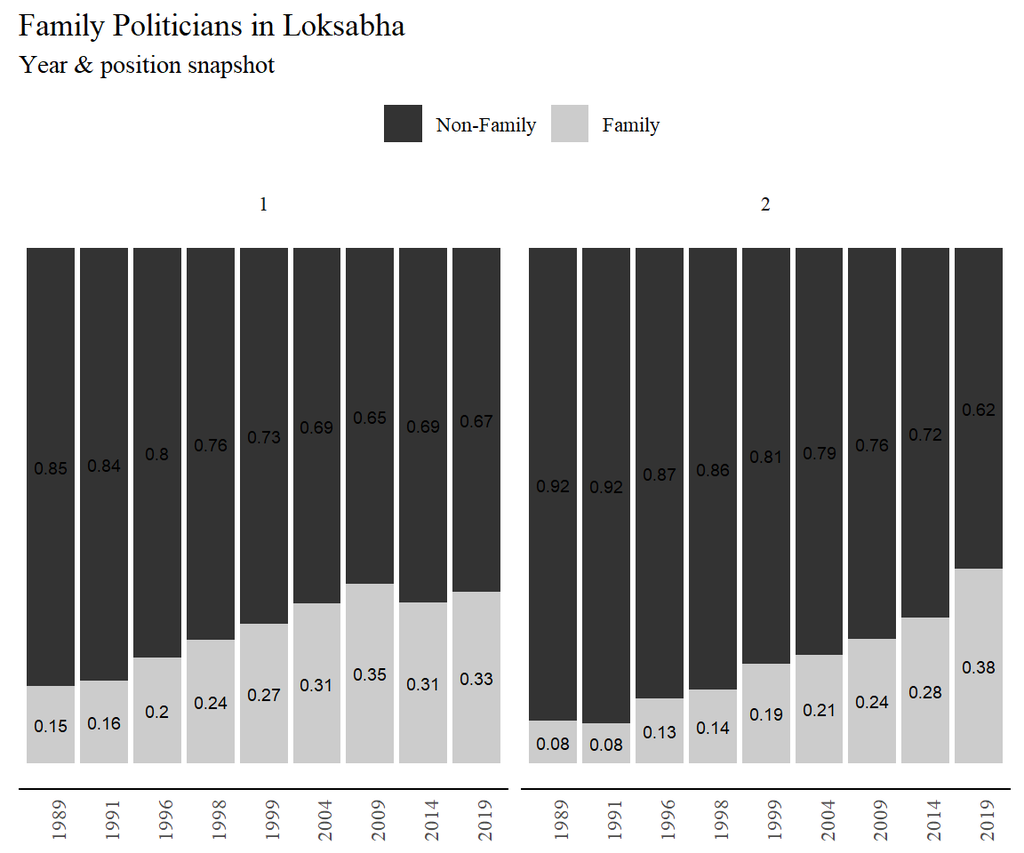

## States

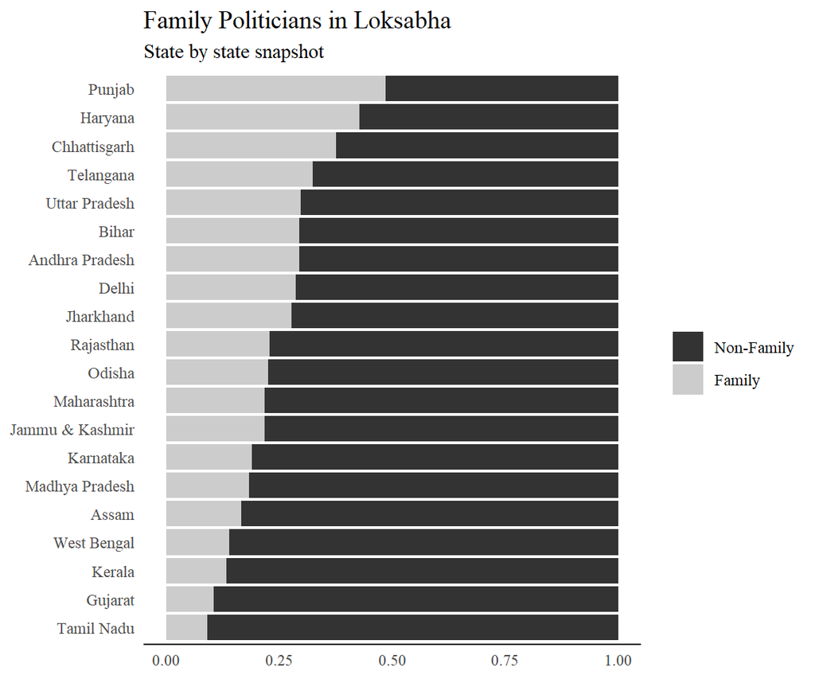